# Name: Caelan Osman

# Class: Math 437

```python
import numpy as np
import matplotlib.pyplot as plt
from scipy.integrate import odeint, solve_ivp, solve_bvp
from scipy.optimize import minimize
plt.rcParams['figure.figsize'] = [10, 5]
```

# Problem 1

Suppose that, in a city of approximately three million, five people who have just become infectious have recently entered the city carrying a certain disease. Each of those individuals has one contact each day that could spread the disease, and an average of three days is spent in the infectious state. Find the solution of the corresponding SIR equations using solve_ivp for fifty days, where each time period is half a day, and plot your results. Use the percentages of each state, not the actual number of people in the state.

At the peak of the infection, how many in the city will still be able to work (assume for simplicity that those who are in the infectious state either cannot go to work or are unproductive, etc.)?

Hint: Use the t-values paramter in solve_ivp to pass in an array of t-values.

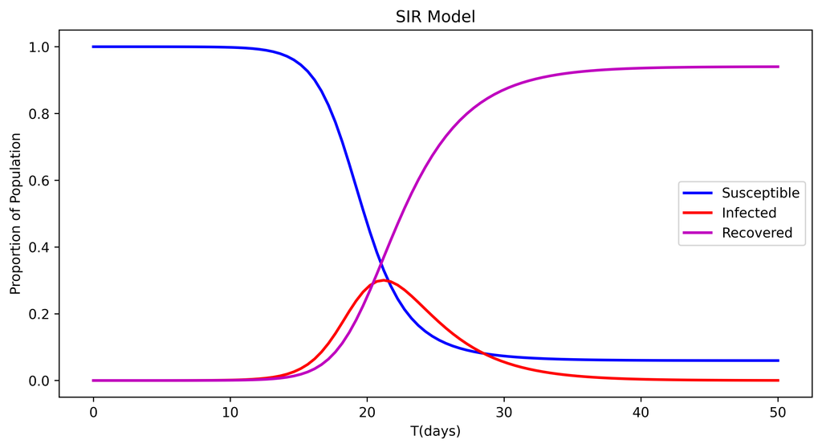

```
2098827
```

```python
def prob1():
    '''This problem solved the SIR model given in problem 1 of the lab manual '''

    def ode(t, y):
        '''defines odes system'''
        beta = 1
        gamma = 1/3
        return np.array([-beta*y[1]*y[0], beta*y[1]*y[0] - gamma*y[1], gamma*y[1]])

    #set initial values and time steps
    t_span = (0, 50)
    t_eval = np.linspace(0, 50, 100)
    #print(t_eval)
    y0 = np.array([2999995/3000000, 5/3000000, 0])

    #solve and plot
    sol = solve_ivp(ode, t_span, y0, t_eval = t_eval)
    fig = plt.figure()
    fig.set_dpi(600)
    plt.plot(sol.t, sol.y[0], color='b', linewidth=2, label='Susceptible')
    plt.plot(sol.t, sol.y[1], color='r', linewidth=2, label='Infected')
    plt.plot(sol.t, sol.y[2], color='m', linewidth=2, label='Recovered')
    plt.legend(loc='best')
    plt.title('SIR Model')
    plt.xlabel('T(days)')
    plt.ylabel('Proportion of Population')
    plt.show()

    return int(3e6 - 3e6 *np.max(sol.y[1]))

prob1()
```

# Problem 2

On March 11, 2020, New York City had 52 confirmed cases of Covid-19. On that day New York started its lock-down measures. Using the following information, model what the spread of the virus could have been if New York did not implement any measures to curb the spread of the virus over the next 150 days: there are approximately 8.399 million people in New York city, the average case of Covid-19 lasts for 10 days, and each infected person can spread the virus to 2.5 people.

Plot your results for each day.

1) At the projected peak, how many concurrent active cases are there?

2) Assuming that about 5% of Covid-19 cases require hospitalization, and using the fact that there are about 58,000 hospital beds in NYC, how much over capacity will the hospitals in NYC be at the projected peak?

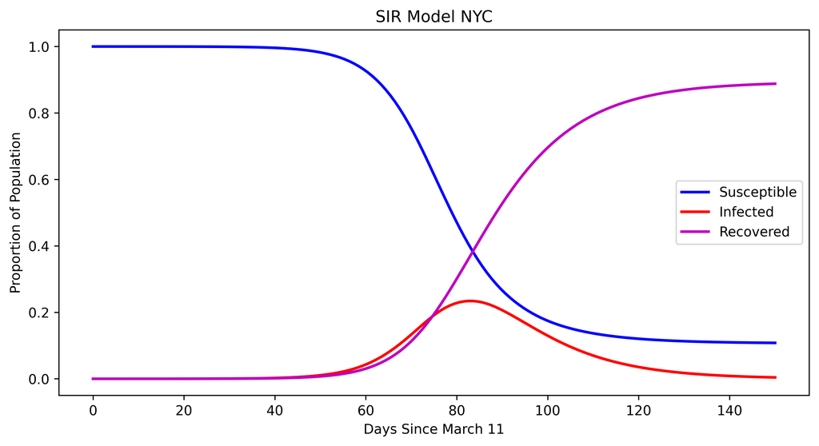

```
(1966483, 40324)
```

```python
def prob2():
    '''
    Using the SIR model, plot a graph that models the
    spead of a disease in NYC and answer the questions.
    1. the projected peak concurent cases
    2. capacity deficit at the projected peak

    returns:
        ans1, ans2: answers to questions 1 and 2
    '''

    '''This problem solved the SIR model given in problem 1 of the lab manual '''

    def ode(t, y):
        '''defines odes system'''
        beta = 2.5/10
        gamma = 1/10
        return np.array([-beta*y[1]*y[0], beta*y[1]*y[0] - gamma*y[1], gamma*y[1]])

    #set initial values and time steps
    t_span = (0, 150)
    t_eval = np.linspace(t_span[0], t_span[-1], t_span[-1])
    y0 = np.array([(8.399e6 - 52)/8.399e6, 52/8.399e6, 0])

    #sovle and plot
    sol = solve_ivp(ode, t_span, y0, t_eval = t_eval)
    fig = plt.figure()
    fig.set_dpi(600)
    plt.plot(sol.t, sol.y[0], color='b', linewidth=2, label='Susceptible')
    plt.plot(sol.t, sol.y[1], color='r', linewidth=2, label='Infected')
    plt.plot(sol.t, sol.y[2], color='m', linewidth=2, label='Recovered')
    plt.legend(loc='best')
    plt.title('SIR Model NYC')
    plt.xlabel('Days Since March 11')
    plt.ylabel('Proportion of Population')
    plt.show()
    return int(8.399e6*np.max(sol.y[1])), int(8.399e6 * 0.05 * np.max(sol.y[1])-58000)

prob2()
```

# Problem 3

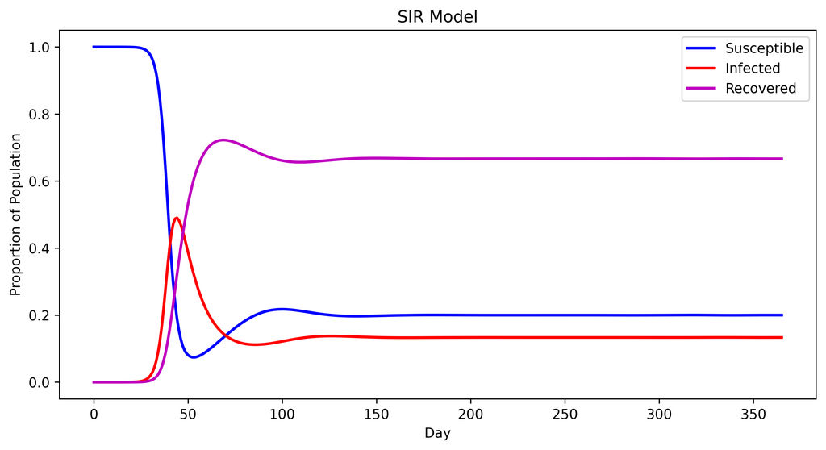

```python
def prob3():
    '''
    Use the SIRS model to examine the spread of the
    flu over the course of a year
    '''
    def ode(t, y):
        '''defines ode system'''
        f, beta, gamma, mu = 1/50, 5/10, 1/10, 0.00001
        system = np.array([f * y[2] + mu*(1 - y[0]) - beta*y[1]*y[0],
                           beta * y[1]*y[0] - (gamma + mu)*y[1],
                          -f*y[2] + gamma * y[1] - mu * y[2]])
        return system

    #set up time span and intial conditions
    t_span = (0, 365)
    t_eval = np.linspace(t_span[0], t_span[-1], t_span[-1])
    y0 = np.array([(7e9 - 1000)/7e9, 1000/7e9, 0])
    #solve and plot
    sol = solve_ivp(ode, t_span, y0, t_eval = t_eval)
    fig = plt.figure()
    fig.set_dpi(600)
    plt.plot(sol.t, sol.y[0], color='b', linewidth=2, label='Susceptible')
    plt.plot(sol.t, sol.y[1], color='r', linewidth=2, label='Infected')
    plt.plot(sol.t, sol.y[2], color='m', linewidth=2, label='Recovered')
    plt.legend(loc='best')
    plt.title('SIR Model')
    plt.xlabel('Day')
    plt.ylabel('Proportion of Population')
    plt.show()
    return

prob3()
```

# Problem 4

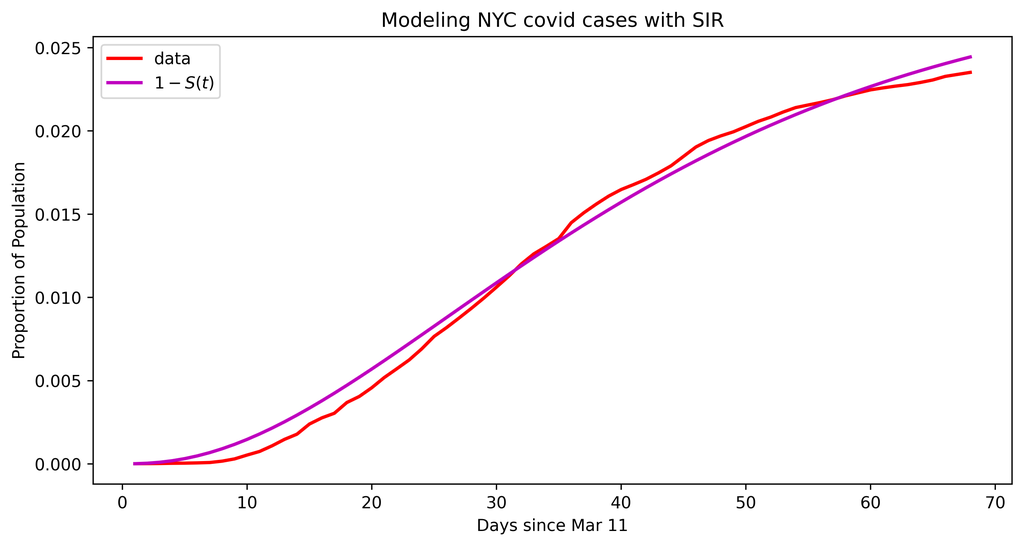

```python
def prob4():
    '''
    Find the best parameters to fit the PEGD model
    to the data provided in new_york_cases.npy
    Plot the data against 1-S(t)
    '''
    #load in data and set conditions
    y = np.load('new_york_cases.npy') /8.399e6
    t_span = (1, y.size)
    ts = np.linspace(t_span[0], t_span[-1], t_span[-1])

    #minimize the odea
    def fun(params):
        '''function used in minimize'''
        alpha, T = params

        def ode(t, y, alpha, T):
            '''defines ode system'''
            return np.array([-alpha *y[1]/t, (alpha/t - 1/T)*y[1], y[1]/T])

        y0 = np.array([(8.399e6 - 52)/8.399e6, 52/8.399e6, 0])
        sol = solve_ivp(ode,  t_span, y0, t_eval = ts, args=(alpha, T))
        out = 1-sol.y[0]
        diff = out - y
        return np.linalg.norm(diff)

    #set intial guess and get minimizers
    p0 = (3, 23)
    alpha, T = minimize(fun, p0).x

    #solve ode with new parameters
    def ode(t, y):
        '''defines ode system'''
        return np.array([-alpha *y[1]/t, (alpha/t - 1/T)*y[1], y[1]/T])

    y0 = np.array([(8.399e6 - 52)/8.399e6, 52/8.399e6, 0])
    sol = solve_ivp(ode, t_span, y0, t_eval = ts)

    #plot normalized data
    fig = plt.figure()
    fig.set_dpi(600)
    plt.plot(ts, y, 'r', lw=2, label = 'data')
    plt.plot(ts, (1 - sol.y[0]), 'm', lw=2, label= r'$1 -S(t)$')
    plt.legend(loc='best')
    plt.title('Modeling NYC covid cases with SIR')
    plt.xlabel('Days since Mar 11')
    plt.ylabel('Proportion of Population')
    plt.show()

    return

prob4()
```

# Problem 5

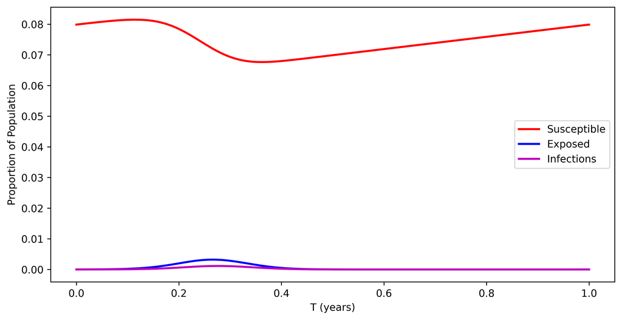

```python
def prob5():
    '''
    Use solve_bvp to model the measles boundary value
    problem
    '''
    #set up ode system and boundary conditions
    def ode_bvp(t, y):
        '''defines ode system'''
        mu, lam, eta = 0.02, 0.0279, 0.01
        b1, b0 = 1, 1575
        beta = lambda t: b0*(1+b1*np.cos(2*np.pi*t))

        system = np.array([mu - beta(t)*y[0]*y[2],
                           beta(t)*y[0]*y[2]-y[1]/lam,
                           y[1] / lam - y[2] /eta,
                            np.zeros_like(t),
                            np.zeros_like(t),
                            np.zeros_like(t)])
        return system

    def bcs(ya, yb):
        '''defines boundary conditions'''
        return np.hstack((ya[0:3] - ya[3:], yb[0:3] - yb[3:]))

    X = np.linspace(0, 1, 365)

    y = np.array([0.075, 0.001, 0.001, 0, 0, 0]).reshape((-1, 1))*np.ones((6, len(X)))

    sol = solve_bvp(ode_bvp, bcs, X, y)
    fig = plt.figure()
    fig.set_dpi(600)
    plt.plot(sol.x, sol.y[0], color='r', linewidth=2, label='Susceptible')
    plt.plot(sol.x, sol.y[1], color='b', linewidth=2, label='Exposed')
    plt.plot(sol.x, sol.y[2], color='m', linewidth=2, label='Infections')
    plt.xlabel('T (years)')
    plt.ylabel('Proportion of Population')
    plt.legend(loc='best')
    plt.show()

    return
prob5()
```